# CRTsampleSearch_Examples

Ruoshui Zhai

October 6, 2019

# Section 1: Using distributions of known forms

The goal of this section is to show you how to use CRTsampleSearch to estimate the optimal number of clusters for a cluster randomization trial (CRT) with examples discussed in our paper where a new simulation-base search method is proposed (link). All the simulation examples in Section 6 of the paper are included in this document.

```r
devtools::install_github("RuoshuiAqua/CRTsampleSearch")
library(CRTsampleSearch)
```

#### uneven cluster sizes

```r
## simulate size of a cluster: log-normal distribution
sim_cluster_size = function(N, ...){
  size = round(100*rlnorm(N, 0, 1), 0)
  size[size<=0] = 1
  print(sigma2n)
  return(size)
}

## continuous outcome: Normal and Normal Two-level Model + fixed_continuous_change
sim_potential_outcomes = function(m,...){
  muibar = rnorm(1, 0, 1)
  Y0 = rnorm(m, muibar, 10)
  Y1 = Y0 + 1
  re = cbind(Y0, Y1)
  colnames(re) = list("Y0", "Y1")
  return(re)
}

## test statistics: pooled difference btw the two arm means
calc_teststat = function(W, data, ...){
  Y0 = data[,"Y0"]
  Y1 = data[,"Y1"]
  re = sum(Y1[W==1])/sum(W==1) - sum(Y0[W==0])/sum(W==0)
  return(re)
}

## CRTsampleSearch
n=CRTsearch(nrep=1e3, nt=20, nc=20, FUN_clustersize=sim_cluster_size, FUN_Ys=sim_potential_outcomes, FUN_TestStat=calc_teststat)


## using formula (Rutterford et cl. 2015)
sigma2n = 1
m = 100 * exp(0 + sigma2n/2) ## average cluster size
m_sd = sqrt(100^2*(exp(sigma2n)-1)*exp(2*0+sigma2n)) ## variance of the cluster size
sigma2 = 1 + 10 ## overall variance
ICC = 1 / 11 ## inter-cluster correlation
alpha = 0.05
minpower=0.8
delta = 1
DE1 = 1+(m-1)*ICC ## Design Effect
N_1 = 2*ceiling(2*sigma2*(qnorm(alpha/2)+qnorm(1-minpower))^2/delta^2*DE1/m)
N_1

## formula with correlation
DE2 = 1+(((m_sd/m)^2+1)*m-1)*ICC ## Design Effect
N_2 = 2*ceiling(2*sigma2*(qnorm(alpha/2)+qnorm(1-minpower))^2/delta^2*DE2/m)
N_2
DE3 = 1/(1-(m_sd/m)^2*m/(m+(1-ICC)/ICC)*(1-m/(m+(1-ICC)/ICC))) ## Design Effect
N_3 = 2*ceiling(2*sigma2*(qnorm(alpha/2)+qnorm(1-minpower))^2/delta^2*DE1*DE3/m)
N_3
```

#### 0-log-Normal continuous outcomes

```r
## simulate size of a cluster: equal cluster size (m=100)
sim_cluster_size = function(N, ...){
  size = rep(100,N)
  return(size)
}

## continuous outcome: Normal and 0-log-Normal Two-level Model + fixed_continuous_change
sim_potential_outcomes = function(m,...){
  muibar = rnorm(1, mean=10, sd=sqrt(10))
  muibar = ifelse(muibar<=0, 0.0001, muibar)
  p0 = 0.2
  v0 = rbinom(m,1,prob=1-p0)
  varlogN = 10
  meanlog = log(muibar / sqrt( varlogN/muibar^2 +1) )
  sd2log = log( varlogN/ muibar^2 +1 )
  Y0 = v0 * rlnorm(m, meanlog, sqrt(sd2log))
  Y1 = Y0 + 1
  re = cbind(Y0, Y1)
  colnames(re) = list("Y0", "Y1")
  return(re)
}

## test statistics: pooled difference btw the two arm means
calc_teststat = function(W, data, ...){
  Y0 = data[,"Y0"]
  Y1 = data[,"Y1"]
  re = sum(Y1[W==1])/sum(W==1) - sum(Y0[W==0])/sum(W==0)
  return(re)
}

## CRTsampleSearch
CRTsearch(nrep=1e4, nt=20, nc=20, FUN_clustersize=sim_cluster_size, FUN_Ys=sim_potential_outcomes, FUN_TestStat=calc_teststat)

## using formula
p0 = 0.2
mu0 = 10
sigma2mui = 10
varlogN = 10
delta = 1
m = 100
sigma2 = (1-p0)*varlogN + p0*(1-p0)*mu0^2 + (1-p0)*sigma2mui
sigma2B = sigma2mui
ICC = sigma2B / sigma2
alpha = 0.05; minpower=0.8
DE = 1+(m-1)*ICC ## Design Effect
N = 2*ceiling(2*sigma2*( qnorm(alpha/2)+qnorm(1-minpower))^2/delta^2/m*DE)
N
```

#### Binary outcomes

```r
## simulate size of a cluster: equal cluster size (m=100)
sim_cluster_size = function(N, ...){
  size = rep(100,N)
  return(size)
}

## binary outcome: beta and bernoulli Two-level Model + dependent bernoulli increase
sim_potential_outcomes = function(m,...){
  pbar=rbeta(1,shape1=1, shape2=5)
  Y0= rbinom(m, size=1, prob=pbar )
  Y1 = rbinom(m, size=1, prob=0.2)*(1-Y0) + Y0
  re = cbind(Y0, Y1)
  colnames(re) = list("Y0", "Y1")
  return(re)
}

## test statistics: pooled difference btw the two arm means
calc_teststat = function(W, data, ...){
  Y0 = data[,"Y0"]
  Y1 = data[,"Y1"]
  re = sum(Y1[W==1])/sum(W==1) - sum(Y0[W==0])/sum(W==0)
  return(re)
}

## CRTsampleSearch
CRTsearch(nrep=1e4, nt=20, nc=20, FUN_clustersize=sim_cluster_size, FUN_Ys=sim_potential_outcomes, FUN_TestStat=calc_teststat)

## using formula
alpha0 = 1
beta0 = 4
delta = 0.05
m = 100
p0 = alpha0/(alpha0+beta0)
p1 = p0 + delta*(1-p0)
sigma2B = (alpha0*beta0)/(alpha0+beta0+1)/(alpha0+beta0)^2
sigma2 = (alpha0*beta0)/(alpha0+beta0)^2
ICCH0 = sigma2B/sigma2
alpha = 0.05; minpower=0.8
DE = 1+(m-1)*ICCH0 ## Design Effect
N = 2*ceiling((p0*(1-p0)+p1*(1-p1))*(qnorm(alpha/2)+qnorm(1-minpower))^2/(p1-p0)^2*DE/m)
N
```

#### Count outcomes

###### Gamma-Poisson Model

```r
## simulate size of a cluster: equal cluster size (m=100)
sim_cluster_size = function(N, ...){
  size = rep(100,N)
  return(size)
}

## count outcome: gamma and poisson Two-level Model + independent poisson increase
sim_potential_outcomes = function(m,...){
  lambdai = rgamma(n=1, shape=10, rate=2)
  Y0 = rpois(m, lambda=lambdai)
  Y1 = rpois(m, lambda=0.1) + Y0
  re = cbind(Y0, Y1)
  colnames(re) = list("Y0", "Y1")
  return(re)
}

## test statistics: pooled difference btw the two arm means
calc_teststat = function(W, data, ...){
  Y0 = data[,"Y0"]
  Y1 = data[,"Y1"]
  re = sum(Y1[W==1])/sum(W==1) - sum(Y0[W==0])/sum(W==0)
  return(re)
}

## CRTsampleSearch
CRTsearch(nrep=1e4, nt=20, nc=20, FUN_clustersize=sim_cluster_size, FUN_Ys=sim_potential_outcomes, FUN_TestStat=calc_teststat)


## using Hayes's formula
alpha0 = 10
beta0 = 2
lambda0 = alpha0 / beta0
delta = 5
lambda1 = lambda0+delta
m = 100
meanY0B = alpha0/beta0
varY0B =alpha0/beta0^2
CV = sqrt(varY0B)/meanY0B
alpha = 0.05; minpower=0.8
N = 2*ceiling(1+(qnorm(alpha/2)+qnorm(1-minpower))^2*((lambda0+lambda1)/m +CV^2*(lambda0^2+lambda1^2))/delta^2)
N
```

###### Gamma-ZIP Model

```r
## simulate size of a cluster: equal cluster size (m=100)
sim_cluster_size = function(N, ...){
  size = rep(100,N)
  return(size)
}

## count outcome: gamma and zero-inflated-poisson (ZIP) Two-level Model + independent poisson increase
sim_potential_outcomes = function(m,...){
  lambdai = rgamma(n=1, shape=10, rate=2)
  Y0c = rpois(m, lambda=lambdai)
  p0=0.2
  Y0b = rbinom(n=m, size=1, prob=1-p0)
  Y0 = Y0c * Y0b
  Y1 = rpois(m, lambda=0.1) + Y0
  re = cbind(Y0, Y1)
  colnames(re) = list("Y0", "Y1")
  return(re)
}

## test statistics: pooled difference btw the two arm means
calc_teststat = function(W, data, ...){
  Y0 = data[,"Y0"]
  Y1 = data[,"Y1"]
  re = sum(Y1[W==1])/sum(W==1) - sum(Y0[W==0])/sum(W==0)
  return(re)
}

## CRTsampleSearch
CRTsearch(nrep=1e4, nt=20, nc=20, FUN_clustersize=sim_cluster_size, FUN_Ys=sim_potential_outcomes, FUN_TestStat=calc_teststat)


## using Hayes's formula
p0=0.2
alpha0 = 10
beta0 = 2
lambda0 = (1-p0)*alpha0/beta0
delta = 1
lambda1 = lambda0+delta
m = 100
meanY0B = (1-p0)*alpha0/beta0
varY0B =(1-p0)^2*alpha0/beta0^2
CV = sqrt(varY0B)/meanY0B
alpha = 0.05; minpower=0.8
N = 2*ceiling(1+(qnorm(alpha/2)+qnorm(1-minpower))^2*((lambda0+lambda1)/m+CV^2*(lambda0^2+lambda1^2))/delta^2)
N
```

# Section 2: Using empirical data distributions

The goal of this section is to show you how to use CRTsampleSearch to estimate the optimal number of clusters for a cluster randomization trial (CRT) when the distributions of baseline outcomes, size of clusters, and study demographics, such as the cluster characteristic used in stratified randomization, are better approximated by emperical distributions collected from previous studies. Specifically, in this document I will repeat the examples in Section 7 of our paper using a synthetic data set generated from the Flu Data in our paper using R synthpop package. The data set is attached in the package.

```r
devtools::install_github("RuoshuiAqua/CRTsampleSearch")
library(CRTsampleSearch)
```

#### The synthetic Flu Data

```r
synFluData_loc = system.file("extdata", "synFluData.csv", package = "CRTsampleSearch")
synFluData = read.csv(synFluData_loc)
```

```r
head(synFluData)
```

```
#>   clusterID patientID rate count time_days time_years race_aa race_aa_pct
#> 1         1         1    0     0       211  0.5776865       0    0.164557
#> 2         1         2    0     0       211  0.5776865       0    0.164557
#> 3         1         3    0     0       211  0.5776865       0    0.164557
#> 4         1         4    0     0       211  0.5776865       0    0.164557
#> 5         1         5    0     0       211  0.5776865       0    0.164557
#> 6         1         6    0     0       211  0.5776865       0    0.164557
#>   race_aa_strata
#> 1              3
#> 2              3
#> 3              3
#> 4              3
#> 5              3
#> 6              3
```

#### Constant change in count or rate

Suppose the intervention in the new study is expected to reduce the number of hospitalization at most one time (some patients never experienced hospitalization in the flu study), the potential outcome under intervention can be simulated from the following $f_1$:
$$f_1: Y_{ij}(1) = max(Y_{ij}(0)-1, 0)$$

```r
sim_potential_outcomes = function(data, ...){
  Y0 = data[,"Y0"]
  Y1 = Y0 - 1 ## effect size = -1
  Y1[Y1<0] = 0
  re = cbind(Y0, Y1)
  colnames(re) = list("Y0", "Y1")
  return(re)
}
calc_teststat = function(W, data, ...){
  Y0 = data[,"Y0"]
  Y1 = data[,"Y1"]
  time = data[,"time_years"]
  re = sum(Y1[W==1])/sum(time[W==1]) - sum(Y0[W==0])/sum(time[W==0])
  return(re)
}
CRTsearch(nrep=10, nt=10, nc=10, dataset=synFluData, outcome="count", clusterID="clusterID", replacement=TRUE, FUN_Ys=sim_potential_outcomes, FUN_TestStat=calc_teststat)
```

If we are interested in the effet of the intervention in terms of changes in hospitaliztion rate, for example suppose the intervention in the new study is expected to reduce the patient-level hospitalization rate by at most 0.4, the potential outcome under intervention can be simulated from the following $f_1$:
$$f_1: Y_{ij}(1) = max(Y_{ij}(0)-0.4, 0)$$

```r
sim_potential_outcomes = function(data, ...){
  Y0 = data[,"Y0"]
  Y1 = Y0 - 0.4 ## effect size = -0.4
  Y1[Y1<0] = 0
  re = cbind(Y0, Y1)
  colnames(re) = list("Y0", "Y1")
  return(re)
}
calc_teststat = function(W, data, ...){
  Y0 = data[,"Y0"]
  Y1 = data[,"Y1"]
  time = data[,"time_years"]
  re = sum(Y1[W==1]*time[W==1])/sum(time[W==1]) - sum(Y0[W==0]*time[W==0])/sum(time[W==0])
  return(re)
}
CRTsearch(nrep=1e4, nt=10, nc=10, dataset=synFluData, outcome="rate", clusterID="clusterID", replacement=TRUE, FUN_Ys=sim_potential_outcomes, FUN_TestStat=calc_teststat)
```

#### Stratified randomization

As the flu study data suggests, the percentage of aferican americans varies among nuring homes (clusters).

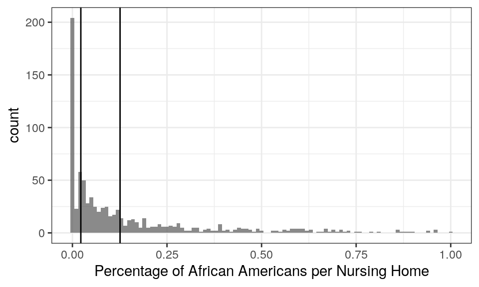

```r
library(ggplot2)
racedist = synFluData[!duplicated(synFluData$clusterID),c("clusterID","race_aa_pct")]
ggplot(data=racedist, aes(racedist$race_aa_pct))+
  geom_histogram(binwidth=0.01, alpha=0.7)+
  xlab("Percentage of African Americans per Nursing Home")+
  theme_bw()+
  geom_vline(xintercept=quantile(racedist$race_aa_pct,0.33))+
  geom_vline(xintercept=quantile(racedist$race_aa_pct,0.67))
```

Suppose the new study adopts stratified randomization, i.e. randomizing sampled clusters within each statum defined by the percentage of african americans in the nursing home, `CRTsampleSearch` should be implemented in the following way using the argument `stratifyBy`:

```r
sim_potential_outcomes = function(data, ...){
  Y0 = data[,"Y0"]
  Y1 = Y0 - 0.4 ## effect size = -0.4
  Y1[Y1<0] = 0
  re = cbind(Y0, Y1)
  colnames(re) = list("Y0", "Y1")
  return(re)
}
calc_teststat = function(W, data, ...){
  Y0 = data[,"Y0"]
  Y1 = data[,"Y1"]
  time = data[,"time_years"]
  re = sum(Y1[W==1]*time[W==1])/sum(time[W==1]) - sum(Y0[W==0]*time[W==0])/sum(time[W==0])
  return(re)
}
CRTsearch(nrep=1e4, nt=15, nc=15, dataset=synFluData, outcome="rate", clusterID="clusterID", stratifyBy="race_aa_strata", replacement=TRUE, FUN_Ys=sim_potential_outcomes, FUN_TestStat=calc_teststat)
```

#### GEE

When the test statistic is the effect of the intervention estimated from a generalized estimating equation (GEE), i.e. $\beta$ from the following model:

$$Y_{ij}^{obs} = Y_{ij}(0)(1-W_{ij}) + Y_{ij}(1) W_{i}$$

$$E(Y_{ij}^{obs}/t_{ij}) = \mu_{ij}; \quad g(\mu_{ij}) = log(\mu_{ij}) = \alpha + W_{i}\beta$$
$$\sum_{i=1}^{n}\Big( \frac{\partial \mu_{i}}{\partial \beta} \Big)^T V_i^{-1}\big(Y_i^{obs} - \mu_i\big) = 0$$
$$\sum_{i=1}^{n}\Big( \frac{\partial \mu_{i}}{\partial \alpha} \Big)^T V_i^{-1}\big(Y_i^{obs} - \mu_i\big) = 0$$
$W_{i}$ is the indicator for intervention assignment at the cluster level, $g(\cdot)$ is the log link function, $V_i$ is a the working covariance matrix of $Y^{obs}_{i}$, $\alpha$ is a constant unknown auxiliary parameter and $\beta$ is the parameter of interest.

```r
sim_potential_outcomes = function(data, ...){
  Y0 = data[,"Y0"]
  Y1 = Y0 - 0.4 ## effect size = -0.4
  Y1[Y1<0] = 0
  re = cbind(Y0, Y1)
  colnames(re) = list("Y0", "Y1")
  return(re)
}
calc_teststat = function(W, data, ...){
  outcome = data[,"Y1"]*W + data[,"Y0"]*(1-W)
  preg = gee::gee(outcome ~ W + offset(data$time_years), id=data$cID, family = "poisson", corstr="exchangeable")
  re = preg$coef[2]
  return(re)
}
CRTsearch(nrep=1e2, nt=15, nc=15, dataset=synFluData, outcome="count", clusterID="clusterID", replacement=TRUE, FUN_Ys=sim_potential_outcomes, FUN_TestStat=calc_teststat)
```

#### Constant change in rate after fitting a zero-inflated poisson (ZIP) model

The flu study demonstrated that the number of hospitalizations includes more 0 counts than expected from a Possion distribution. We can fit a ZIP model for each nursing home.

```r
# estimating the amount of inflaction per cluster
clusterID = unique(synFluData$clusterID)
for(i in 1:816){
  dtmp = synFluData[synFluData$clusterID==clusterID[i],]
  clusterSize = dim(dtmp)[1]
  fit = pscl::zeroinfl(count ~  offset(log(time_years)) , data=dtmp, dist="poisson", link="logit")
  clusterP0 = 1/(1+exp(-fit$coefficients$zero))
  clusterLambda0 = exp(fit$coefficients$count)
  synFluData$clusterP0[synFluData$clusterID==clusterID[i]] = clusterP0
  synFluData$clusterLambda0[synFluData$clusterID==clusterID[i]] = clusterLambda0
  synFluData$clusterSize[synFluData$clusterID==clusterID[i]] = clusterSize
}
head(synFluData)
```

```
#>   clusterID patientID rate count time_days time_years race_aa race_aa_pct
#> 1         1         1    0     0       211  0.5776865       0    0.164557
#> 2         1         2    0     0       211  0.5776865       0    0.164557
#> 3         1         3    0     0       211  0.5776865       0    0.164557
#> 4         1         4    0     0       211  0.5776865       0    0.164557
#> 5         1         5    0     0       211  0.5776865       0    0.164557
#> 6         1         6    0     0       211  0.5776865       0    0.164557
#>   race_aa_strata clusterP0 clusterLambda0 clusterSize
#> 1              3 0.8228683      0.3444041          79
#> 2              3 0.8228683      0.3444041          79
#> 3              3 0.8228683      0.3444041          79
#> 4              3 0.8228683      0.3444041          79
#> 5              3 0.8228683      0.3444041          79
#> 6              3 0.8228683      0.3444041          79
```

The proportion of zero-inflation varies among nurisng homes.

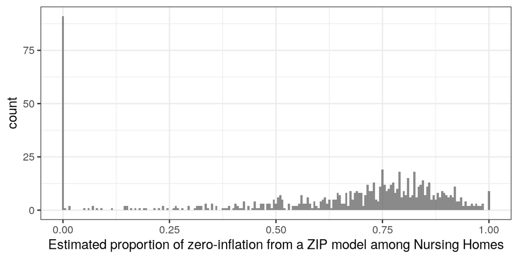

```r
synfluZIP = synFluData[!duplicated(synFluData$clusterID),c("clusterID","clusterP0","clusterLambda0")]
ggplot(data=racedist, aes(synfluZIP$clusterP0))+
  geom_histogram(binwidth=0.005, alpha=0.7)+
  xlab("Estimated proportion of zero-inflation from a ZIP model among Nursing Homes")+
  theme_bw()
```

The hospitalization rate after adjusting for the zero-inflation also varies among nursing homes.

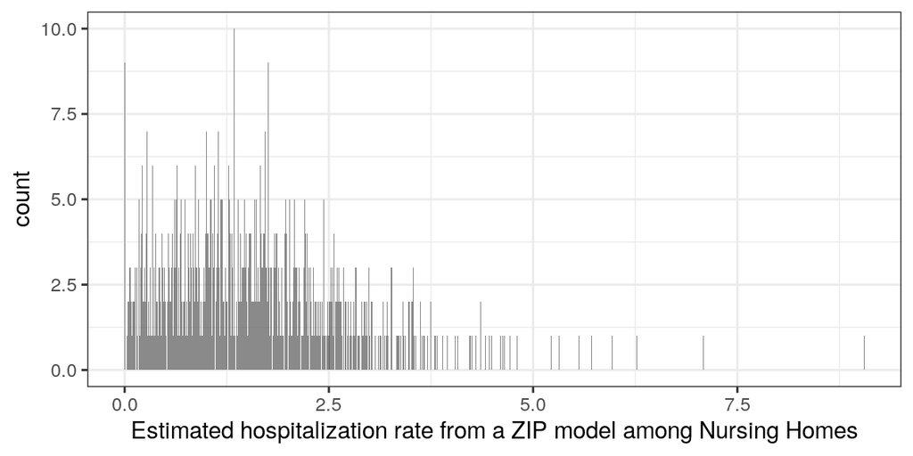

```r
ggplot(data=racedist, aes(synfluZIP$clusterLambda0))+
  geom_histogram(binwidth=0.01, alpha=0.7)+
  xlab("Estimated hospitalization rate from a ZIP model among Nursing Homes")+
  theme_bw()
```

Suppose the intervention is expected to reduce the number of hospitalization for the “sub-population” of patients who is ever expected to experience hospitalization, i.e. the Possion part of the ZIP model, the potential outcome under intervention can be simulated from the feollowing $f_1$:
$$f_1: Y_{ij}(1) \sim ZIP(P_i, max(\lambda_i-0.1, 0)\}$$
$P_i$ and $\lambda_i$ are the proportion of zero-inflation and event rate estimated using a ZIP for nursing home $i$.

```r
sim_potential_outcomes = function(data, ...){
  Y0 = data[,"Y0"]
  lambda1 = data[,"clusterLambda0"] - 0.1 ## effect size = -0.1
  lambda1 = ifelse(lambda1<=0,0,lambda1)
  clusterP1 = data[,"clusterP0"]
  Y1 = sapply(lambda1*data[,"time_years"], rpois, n=1)
  zerocount = sapply(1-clusterP1,rbinom,n=1,size=1)
  Y1 = Y1*zerocount
  re = cbind(Y0, Y1)
  colnames(re) = list("Y0", "Y1")
  return(re)
}
calc_teststat = function(W, data, ...){
  Y0 = data[,"Y0"]
  Y1 = data[,"Y1"]
  time = data[,"time_years"]
  re = sum(Y1[W==1])/sum(time[W==1]) - sum(Y0[W==0])/sum(time[W==0])
  return(re)
}
CRTsearch(nrep=1e4, nt=10, nc=10, dataset=synFluData, outcome="count", clusterID="clusterID", replacement=TRUE, FUN_Ys=sim_potential_outcomes, FUN_TestStat=calc_teststat)
```

#### Infinite study population vs finite population

```r
set.seed(2019)
subset16 = sample(unique(synFluData$clusterID),16)
synFluData16 = synFluData[synFluData$clusterID %in% subset16,]
```

The power for sample size from 10 to 20 is calculated in the following way. Note that when sampling without replacement, the maximum number of clusters is 16.

```r
sim_potential_outcomes = function(data, ...){
  Y0 = data[,"Y0"]
  Y1 = Y0 - 0.4
  Y1[Y1<0] = 0
  re = cbind(Y0, Y1)
  colnames(re) = list("Y0", "Y1")
  return(re)
}
calc_teststat = function(W, data, ...){
  Y0 = data[,"Y0"]
  Y1 = data[,"Y1"]
  time = data[,"time_years"]
  re = sum(Y1[W==1]*time[W==1])/sum(time[W==1]) - sum(Y0[W==0]*time[W==0])/sum(time[W==0])
  return(re)
}

power16 = NULL
for(n in 5:10){
  if(n*2>16){
    power16_finite = NA
  }else{
    power16_finite = simPower(nrep=1e4, nt=n, nc=n, dataset=synFluData, outcome="rate", clusterID="clusterID", replacement=FALSE, FUN_Ys=sim_potential_outcomes, FUN_TestStat=calc_teststat)
    power16_finite_PT = simPowerPT(nrep=1e4, nt=n, nc=n, dataset=synFluData, outcome="rate", clusterID="clusterID", replacement=FALSE, FUN_Ys=sim_potential_outcomes, FUN_TestStat=calc_teststat)
  }
  power16_infinite = simPower(nrep=1e4, nt=n, nc=n, dataset=synFluData, outcome="rate", clusterID="clusterID", replacement=TRUE, FUN_Ys=sim_potential_outcomes, FUN_TestStat=calc_teststat)

  power16_i = cbind(n*2, power16_finite, power16_finite_PT, power16_infinite)
  colnames(power16_i) = list("ntotal", "power16_finite", "power16_finite_PT", "power16_infinite")
  power16 = rbind(power16, power16_i)
}
power16
```

#### Extend followup time

$$f_0: Y_{ij}(0) \sim \big( \lambda_0 * t + Poisson(\lambda_0*\Delta t) \big) / \big( t + \Delta t\big)$$

If the previous study data suggests that a patient were not followed till the end of the study, it does not make sense to extend the follow-up time for them. So $\Delta t =0$ for patients who were not followed for a full 211 days in the flu study. Users should specify a lostfollowup argument in `CRTsearch` as follows:

```r
sim_potential_outcomes = function(data, ...){
  Y0 = data[,"Y0"]
  Y1 = Y0 - 0.4 ## effect size = -0.4
  Y1[ Y1 < 0 ] = 0
  extendtime = 0.25
  Y0count = Y0*data[,"time_years"]
  Y0count_extend = rpois(1,Y0*extendtime)
  Y1count = Y1*data[,"time_years"]
  Y1count_extend = rpois(1,Y1*extendtime)
  Y1 = (Y1count + Y1count_extend*(1-data[,"lostfollowup"]))/(data[,"time_years"]+extendtime*(1-data[,"lostfollowup"]))
  Y0 = (Y0count + Y0count_extend*(1-data[,"lostfollowup"]))/(data[,"time_years"]+extendtime*(1-data[,"lostfollowup"]))
  re = cbind(Y0, Y1)
  colnames(re) = list("Y0", "Y1")
  return(re)
}

calc_teststat = function(W, data, ...){
  Y0 = data[,"Y0"]
  Y1 = data[,"Y1"]
  extendtime = 0.25
  time = data[,"time_years"] + extendtime*(1-data[,"lostfollowup"])
  re = sum(Y1[W==1]*time[W==1])/sum(time[W==1]) - sum(Y0[W==0]*time[W==0])/sum(time[W==0])
  return(re)
}

synFluData16$lostfollowup = ifelse(synFluData16$time_days < 211, 1 , 0)

power_extendtime=NULL
for(addtime in seq(0, 1, 0.25)){
  power_i = simPower(nrep=1e4, nt=8, nc=8, dataset=synFluData16, outcome="rate", clusterID="clusterID", replacement=FALSE, FUN_Ys=sim_potential_outcomes, FUN_TestStat=calc_teststat, extendtime=addtime)
  power_extendtime = rbind(power_extendtime, cbind(addtime, power_i))
}
power_extendtime
```